# Final Project R Reference

# R Reference Guide

## Loading Data and Packages

##### To clear global environment

```r
rm(list = ls())
```

### require & library

###### Use `require` or `library` to load R packages within your directory.

```r
require(here)
require(palmerpenguins)
library(here)
```

### here

###### Use `here` to find project files starting at your working directory.

```r
here("data", "ginkgo_data_2021.csv")
```

```
## [1] "/Users/Umass/Documents/ECO634/environmental_data/env_data_git_second/data/ginkgo_data_2021.csv"
```

### Create data frame from .csv

```r
gingko = read.csv(here("data", "ginkgo_data_2021.csv"))

summary(gingko)
```

```
##     site_id      seeds_present     max_width        max_depth
##  Min.   : 1896   Mode :logical   Min.   : 16.00   Min.   : 19.00
##  1st Qu.: 3703   FALSE:636       1st Qu.: 63.00   1st Qu.: 43.00
##  Median : 6066   TRUE :120       Median : 74.00   Median : 51.00
##  Mean   : 6079                   Mean   : 74.34   Mean   : 58.51
##  3rd Qu.: 7206                   3rd Qu.: 85.00   3rd Qu.: 66.00
##  Max.   :12982                   Max.   :130.00   Max.   :145.00
##
##   notch_depth    petiole_length
##  Min.   : 0.00   Min.   :  8.00
##  1st Qu.: 0.00   1st Qu.: 34.00
##  Median : 0.00   Median : 47.00
##  Mean   : 2.99   Mean   : 48.25
##  3rd Qu.: 4.00   3rd Qu.: 60.00
##  Max.   :49.00   Max.   :113.00
##                  NA's   :4
```

## Data Structures

### c()

##### The function `c()` combines or concatenates its arguments into a vector (a 1-dimensional data structure consisting of 1 or more elements).

- All of the elements must be of the same type.
- I can’t combine character and numeric types in the same call to c()

Here are two examples using numeric and character data types:

```r
## Create a vector of numbers:
num_vec  = c(1, 4, 8, 9, 13)

## Create a vector of characters:
char_vec = c("a", "fish", "data is cool")
```

Show the contents of a vector by typing the name of the vector, or using the print() function.

```r
## Typing the name of the vector into the console prints the contents
num_vec
```

```
## [1]  1  4  8  9 13
```

```r
## The print() function accomplishes the same task:
print(char_vec)
```

```
## [1] "a"            "fish"         "data is cool"
```

### length()

##### `Length()` retrieves the length of vectors, lists, and factors. It can be applied to one column or row of a dataset, or any other string of factors, lists, or wherever a vector may appear.

The following example retrieves the number of values in the vector:

```r
length(c(1, 6, 4, 8, 9, 6, 55, 6, 7, 88))
```

```
## [1] 10
```

The following example returns the number of observations under the “species” column.

```r
require(palmerpenguins)
length(penguins$species)
```

```
## [1] 344
```

### matrix()

###### To create a matrix:

Arguments: matrix(data = NA, nrow = 1, ncol = 1, byrow = FALSE, dimnames = NULL)

- `data` is the data source (ex. `penguins` dataset)
- `nrow` is the row to select (or number of rows to create)
- `ncol` is column to select (or number of columns to create)
- `byrow = TRUE` orders by row, `FALSE` orders by column

```r
mat_1 <- matrix(1:20,
                ncol = 4,
                )
```

### nrow()

`nrow` retrieves (or sets) the number of rows from a data frame

```r
nrow(gingko)
```

```
## [1] 756
```

### ncol()

`ncol()` retrieves (or sets) the number of columns from a data frame

```r
ncol(gingko)
```

```
## [1] 6
```

### dim()

`dim` retrieves the dimensions of a vector or dataframe. `dimnames` sets names for rows and columns during matrix creation.

```r
dim(gingko)
```

```
## [1] 756   6
```

## Subsetting

#### Subsetting retrieves specific values, rows, columns, characters, or variables from a dataset (ex. vector, matrix, or data frame). Subsetting can also be used to add or subtract fields to/from data frames, matrices, and vectors

The following operations all perform subsetting.

### $

```r
summary(gingko$max_width)
```

```
##    Min. 1st Qu.  Median    Mean 3rd Qu.    Max.
##   16.00   63.00   74.00   74.34   85.00  130.00
```

### []

Use `[]` to subset by position

- Can be used on 2 and 3-Dimensional vectors

```r
gingko[1,] # select first row of the data frame
```

```
##   site_id seeds_present max_width max_depth notch_depth petiole_length
## 1    7719         FALSE        71        40           0             30
```

```r
gingko[2,3] # select the element in row 2, column 3
```

```
## [1] 64
```

```r
head(gingko[, "max_width"]) #select the 3rd column of the data frame
```

```
## [1] 71 64 55 62 65 70
```

### subset

`subset` is a more versatile version of the operation that has the `droplevels` argument in case you need to remove subsets of variables or values from a data set.

```r
penguins = palmerpenguins::penguins
?subset
head(subset(penguins, species == "Adelie"))
```

```
## # A tibble: 6 × 8
##   species island bill_length_mm bill_depth_mm flipper_length_… body_mass_g sex
##   <fct>   <fct>           <dbl>         <dbl>            <int>       <int> <fct>
## 1 Adelie  Torge…           39.1          18.7              181        3750 male
## 2 Adelie  Torge…           39.5          17.4              186        3800 fema…
## 3 Adelie  Torge…           40.3          18                195        3250 fema…
## 4 Adelie  Torge…           NA            NA                 NA          NA <NA>
## 5 Adelie  Torge…           36.7          19.3              193        3450 fema…
## 6 Adelie  Torge…           39.3          20.6              190        3650 male
## # … with 1 more variable: year <int>
```

## Numerical Data Exploration

### summary()

Use `summary` to retrieve these values for a dataset:

- minimum
- 1st Quartile
- Median
- Mean
- 3rd Quartile
- Maximum

```r
summary(gingko$max_width)
```

```
##    Min. 1st Qu.  Median    Mean 3rd Qu.    Max.
##   16.00   63.00   74.00   74.34   85.00  130.00
```

### mean()

Use `mean` to retrieve the mean value for a set of values

```r
mean(gingko$max_width)
```

```
## [1] 74.33823
```

### sd()

Use `sd` to retrieve the standard deviation of a set of values

```r
sd(gingko$max_width)
```

```
## [1] 16.4203
```

## Graphical Data Exploration

### Use `plot()` to create scatterplots of variables

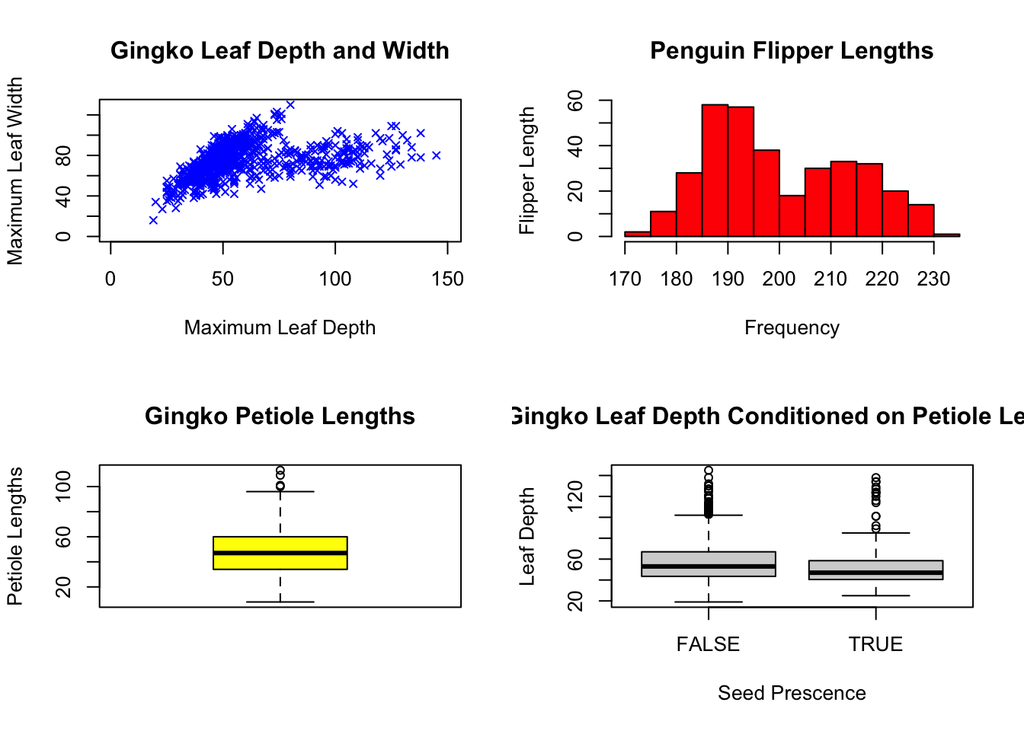

```r
par(mfrow = c(2, 2))

plot(x = gingko$max_depth, y = gingko$max_width,
    col = "blue", #  Color
    pch = 4,  #  Point type
    cex = .75, #  Point size
    main = "Gingko Leaf Depth and Width", # Header/Title
    xlab = "Maximum Leaf Depth", # X-axis label
    ylab = "Maximum Leaf Width", # Y-axis Label
    xlim = c(1, 150), # X-axis range
    ylim = c(0, 130),  # Y-axis range
)

hist(penguins$flipper_length_mm, main = "Penguin Flipper Lengths",
     xlab = "Frequency",
     ylab = "Flipper Length",
     breaks = 10, # Higher value = greater number of bins
     col = "red",
     )

boxplot(gingko$petiole_length, main = "Gingko Petiole Lengths",
        ylab = "Petiole Lengths",
        col = "yellow")

boxplot(formula = max_depth ~ seeds_present,
        data = gingko,
        main = "Gingko Leaf Depth Conditioned on Petiole Length",
        ylab = "Leaf Depth",
        xlab = "Seed Prescence",
        ls = 2)
```

### hist()

Use `hist()` to create a histogram from given data

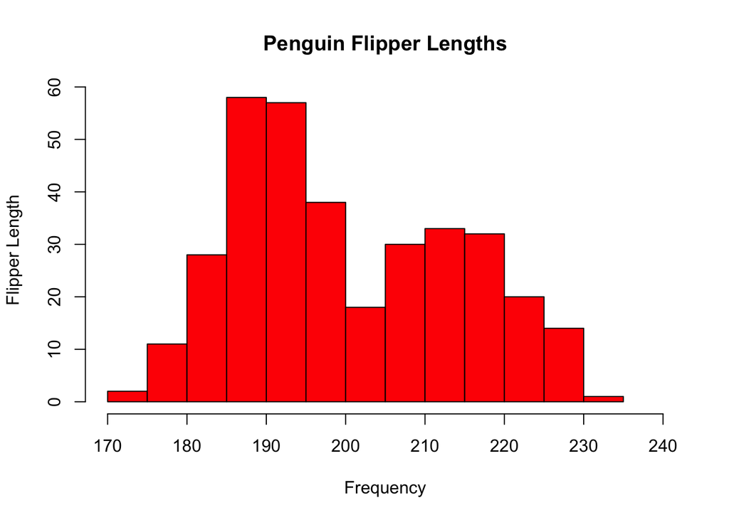

```r
hist(penguins$flipper_length_mm, main = "Penguin Flipper Lengths",
     xlab = "Frequency",
     ylab = "Flipper Length",
     breaks = 10, # Higher value = greater number of bins
     col = "red",
     xlim = c(170, 240)
     )
```

### boxplot

Use `boxplot()` to create boxplots of given data.

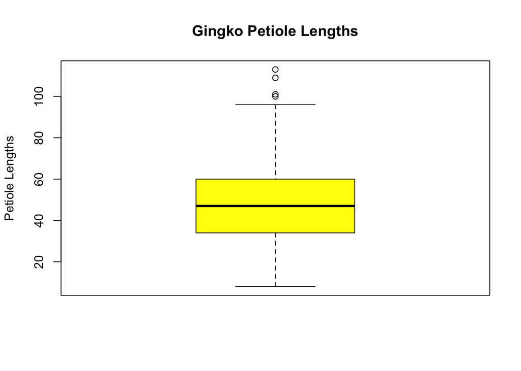

```r
boxplot(gingko$petiole_length, main = "Gingko Petiole Lengths",
        ylab = "Petiole Lengths",
        col = "yellow")
```

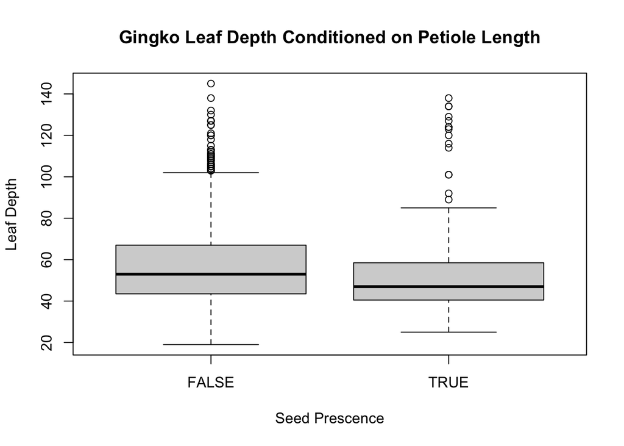

```r
boxplot(formula = max_depth ~ seeds_present,
        data = gingko,
        main = "Gingko Leaf Depth Conditioned on Petiole Length",
        ylab = "Leaf Depth",
        xlab = "Seed Prescence",
        ls = 2)
```

## Distribution Functions

### Normal Distribution

- `dnorm` returns the density function for a normally distributed dataset
- `pnorm`returns the distribution function for a normally distributed dataset
- `qnorm` returns the quantile function for a normally distributed dataset

##### pnorm()

`pnorm()` is a local function in R an is used retrieve the value of the cumulative density function for normally-distributed data using a given `mean`, and standard deviation `sd`

`pnorm(q, mean = 0, sd = 1, lower.tail = TRUE, log.p = FALSE)`

##### qnorm()

`qnorm(p, mean = 0, sd = 1, lower.tail = TRUE, log.p = FALSE)`

### Binomial Distribution

##### dbinom()

`dbinom(x, size, prob, log = FALSE)`

```r
dbinom(0, 6, 2/3)
```

```
## [1] 0.001371742
```

##### pbinom()

`pbinom(q, size, prob, lower.tail = TRUE, log.p = FALSE)`

```r
pbinom(4, 6, 2/3)
```

```
## [1] 0.648834
```

##### qbinom()

`qbinom(p, size, prob, lower.tail = TRUE, log.p = FALSE)`